# Logistic Regression and Classification

Krzysztof Mierzejewski

01-04-2018

Wczytanie wymaganych pakietów.

```r
library(ISLR)
data(Default)
```

# 1 Binaryzacja wartości wyliczeniowych

Domyślna wartość *dummy variable*.

```r
print(contrasts(Default$default))
```

```
    Yes
No    0
Yes   1
```

```r
print(contrasts(Default$student))
```

```
    Yes
No    0
Yes   1
```

Możliwe jest bezpośrednie zdefiniowanie wartości *dummy variable* w przypadku, gdy funkcja `contrasts` zwraca niepożądane wartości.

```r
data<-cbind(Default, data.frame(student.Yes=ifelse(Default$student=="Yes", 1, 0),
                                default.Yes=ifelse(Default$default=="Yes", 1, 0)))
```

# 2 Model regresji logistycznej

Funkcja logistyczna: $p(X)=\frac{e^{\beta_0+\beta_1X_1+\dotsb+\beta_pX_p}}{1+e^{\beta_0+\beta_1X_1+\dotsb+\beta_pX_p}}$.

## 2.1 Trenowanie modelu *Default ~ Balance*

```r
est<-glm(default~balance, data=Default, family=binomial(link="logit"))
```

```
Call:
glm(formula = default ~ balance, family = binomial(link = "logit"),
    data = Default)

Deviance Residuals:
    Min       1Q   Median       3Q      Max
-2.2697  -0.1465  -0.0589  -0.0221   3.7589

Coefficients:
              Estimate Std. Error z value Pr(>|z|)
(Intercept) -1.065e+01  3.612e-01  -29.49   <2e-16 ***
balance      5.499e-03  2.204e-04   24.95   <2e-16 ***
---
Signif. codes:  0 ‘***’ 0.001 ‘**’ 0.01 ‘*’ 0.05 ‘.’ 0.1 ‘ ’ 1

(Dispersion parameter for binomial family taken to be 1)

    Null deviance: 2920.6  on 9999  degrees of freedom
Residual deviance: 1596.5  on 9998  degrees of freedom
AIC: 1600.5

Number of Fisher Scoring iterations: 8
```

## 2.2 Współczynniki modelu regresji logistycznej.

```r
coef(est)  # to samo co print(summary(est)$coefficients[,"Estimate"])
```

```
  (Intercept)       balance
-10.651330614   0.005498917
```

## 2.3 Prognoza

`type="response"` powoduje zwrócenie wartości w postaci $P(Y=1 \mid X)$.

```r
sprintf("%.2f%%", predict(est, newdata = data.frame(
  balance=c(median(Default$balance), 1500, 1900, max(Default$balance))), type="response") * 100)
```

```
[1] "0.22%"  "8.29%"  "44.93%" "98.10%"
```

## 2.4 Prawdopodobieństwo, Logit i szansa

### 2.4.1 Prawdopodobieństwo

Definicja funkcji prawdopodobieństwo $p(X)$.

```r
B1=coef(est)[["balance"]]
B0=coef(est)[["(Intercept)"]]
p<-function(x) exp(B1*x+B0)/(1+exp(B1*x+B0))
```

### 2.4.2 Szansa (ang. *odds*)

$\frac{p(X)}{1-p(X)}=e^{\beta_0+\beta_1X_1+\dotsb+\beta_pX_p}$.

Definicja funkcji *szansa*.

```r
Odds<-function(x) exp(B0+B1*x)
```

### 2.4.3 Logit

$\log\left(\frac{p(X)}{1-p(X)}\right)=\beta_0+\beta_1X_1+\dotsb+\beta_pX_p$.

Definicja funkcji *Logit*.

```r
Logit<-function(x) B0+B1*x
```

Wartości prawdopodobieństwa, szansy oraz funkcji Logit dla nowej obserwacji *zadłużenie = $1900*.

```r
sprintf("p(1900)=%.2f%%", 100*p(1900))
paste("Odds(1990)=", signif(Odds(1900), 5), sep = "")
paste("Logit(1900)=", signif(Logit(1900), 5), sep="")
```

```
p(1900)=44.93%
Odds(1990)=0.81596
Logit(1900)=-0.20339
```

Te same wartości z użyciem funkcji `predict.glm`.

```r
predict.glm(est, newdata = data.frame(balance=1900), type="response")
exp(predict(est, newdata = data.frame(balance=1900)))
predict.glm(est, newdata = data.frame(balance=1900))
```

```
0.4493274
0.8159612
-0.2033884
```

# 3 Wizualizacja

Wykres dystrybuanty rozkładu logistycznego. Na osi rzędnych prawdopodobieństwo problemów ze spłatą karty (*default*) w zależności od zadłużenia (*balance*) na osi odciętych. Kolorem czerwonym zaznaczone są obserwacje klientów, którzy faktycznie karty nie spłacają (*default*); czarnym natomiast klienci regulujący zobowiązania.

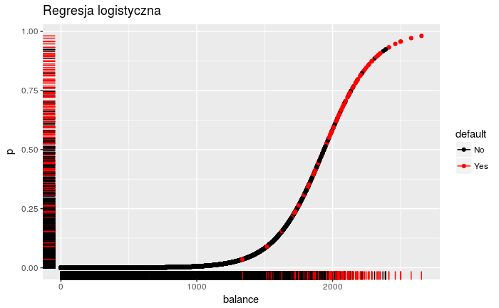

# 4 Klasyfikacja

Trafność (ang. *accuracy*) klasyfikacji dychotomicznej zbioru trenującego przy zadanym progu prawdopodobieństwa 50%.

```r
Default.pred<-rep("No", nrow(Default))
Default.pred[Default.probs > .5]<-"Yes"
table(Default.pred)
```

```
Default.pred
  No  Yes
9858  142
```

Macierz pomyłek (ang. *confusion matrix* / *truth table*).

```r
print(table(Default.pred, Default$default))
```

```
Default.pred   No  Yes
         No  9625  233
         Yes   42  100
```

Trafność.

```r
sprintf("%.2f%%", 100 * mean(Default.pred==Default$default))
```

```
[1] "97.25%"
```

## 4.1 Podział na zbiór trenujący i walidujący metodą *hold-out*

Trenowanie modelu.

```r
set.seed(30112)                              # ustawienie ziarna generatora liczb losowych.
library(caret)
partition<-createDataPartition(
  Default$default, p=.9, list=FALSE)
est<-glm(default~balance, data=Default,
         family=binomial, subset=partition)
```

Alternatywnie.

```r
Default.train<-rep(FALSE, nrow(Default))
Default.train[sample(1:nrow(Default), 0.9*nrow(Default))]<-TRUE
est<-glm(default~balance, data=Default, family=binomial, subset=Default.train)
```

[output not shown]

## 4.2 Macierz pomyłek

Prognoza / Rzeczywista wartość

|  | Act.False | Act.True |
| --- | --- | --- |
| Est.False | True Negative | False Negative / II |
| Est.True | False Positive / I | True Positive |

Wektory prognozy prawdopodobieństwa oraz klasyfikacji przy zadanym progu prawdopodobieństwa 50%.

```r
Default.probs<-predict(est, type="response", newdata = Default[-partition,])
Default.pred<-rep("No", length(Default.probs))
Default.pred[Default.probs > .5]<-"Yes"
valVect<-Default[-partition, "default"]
```

Alternatywnie.

```r
Default.probs<-predict(est, type="response", newdata = Default[!Default.train,])
Default.pred<-rep("No", length(Default.probs))
Default.pred[Default.probs > .5]<-"Yes"
valVect<-Default[!Default.train,"default"]
```

Macierz pomyłek.

```r
confusionMatrix<-table(Default.pred, valVect, dnn=c("Predicted","Actual"))
rownames(confusionMatrix)<-c("Predicted.No", "Predicted.Yes")
colnames(confusionMatrix)<-c("Actual.No", "Actual.Yes")
print(confusionMatrix)
```

```
               Actual
Predicted       Actual.No Actual.Yes
  Predicted.No        960         25
  Predicted.Yes         6          8
```

## 4.3 Współczynniki klasyfikacji

[figure not shown]

```r
P<-sum(confusionMatrix[,"Actual.Yes"])
N<-sum(confusionMatrix[,"Actual.No"])
TP<-confusionMatrix["Predicted.Yes", "Actual.Yes"]
FP<-confusionMatrix["Predicted.Yes", "Actual.No"]
FN<-confusionMatrix["Predicted.No", "Actual.Yes"]
TN<-confusionMatrix["Predicted.No", "Actual.No"]
```

Alternatywnie *P* i *N*.

```r
P<-TP+FN
N<-FP+TN
```

### 4.3.1 Trafność (ang. *accuracy*)

```r
Rate.ACC<-(TP+TN)/sum(confusionMatrix)
```

Alternatywnie.

```r
Rate.ACC<-(TP+TN)/(P+N)
```

```
[1] 0.968969
```

### 4.3.2 Błąd klasyfikacji (ang. *error*)

```r
Rate.Err<-(FP+FN)/sum(confusionMatrix)
```

Alternatywnie.

```r
Rate.Err<-(FP+FN)/(P+N)
Rate.Err<-1-ACC
```

```
[1] 0.03103103
```

### 4.3.3 Czułość / zwrot (ang. *sensitivity* / *recall*)

```r
Rate.TPR<-TP/P
```

```
[1] 0.2424242
```

### 4.3.4 False Negative rate

```r
Rate.FNR<-FN/P  # to samo co Rate.FNR<-1-Rate.TPR
```

```
[1] 0.7575758
```

### 4.3.5 Specyficzność (ang. *specificity*)

```r
Rate.TNR<-TN/N
```

```
[1] 0.9937888
```

### 4.3.6 False Positive rate / Fall-out

```r
Rate.FPR<-FP/N  # to samo co Rate.FPR<-1-Rate.TNR
```

```
[1] 0.00621118
```

### 4.3.7 Precyzja (ang. *precision*)

```r
Rate.PPV<-TP/(TP+FP)  # to samo co Rate.PPV<-TP/sum(confusionMatrix["Predicted.Yes",])
```

```
[1] 0.5714286
```

### 4.3.8 F-miara (ang. *F1 score*)

```r
Rate.F1<-2*TP/(2*TP+FP+FN)  # to samo co Rate.F1<-2*TP/(sum(Default.pred!=valVect)+2*TP)
```

```
[1] 0.3404255
```

## 4.4 Zastosowanie pakietu `SDMTools`

Macierz pomyłek z użyciem funkcji `SDMTools::confusion.matrix`.

```r
library("SDMTools")
confusion.matrix(ifelse(valVect=="Yes", 1, 0), ifelse(Default.pred=="Yes", 1, 0))
```

```
    obs
pred   0  1
   0 960 25
   1   6  8
attr(,"class")
[1] "confusion.matrix"
```

# 5 Zbiór walidujący

## 5.1 Wizualizacja

```r
score_data<-data.frame(balance=Default[-partition, "balance"],
                       p=Default.probs, default=valVect)
```

Alternatywnie.

```r
score_data<-data.frame(balance=Default[!Default.train, "balance"],
                       p=Default.probs, default=valVect)
```

Wykres dystrybuanty rozkładu logistycznego dla zbioru walidującego. Na osi rzędnych prawdopodobieństwo problemów ze spłatą karty (*default*) w zależności od zadłużenia (*balance*) na osi odciętych. Kolorem czerwonym zaznaczone są obserwacje klientów, którzy faktycznie karty nie spłacają (*default*); czarnym natomiast klienci regulujący zobowiązania.  
Można zaobserwować jak wraz ze zmianą progu prawdopodobieństwa klasyfikacji zmieniać się będą współczynniki precyzji oraz czułości.

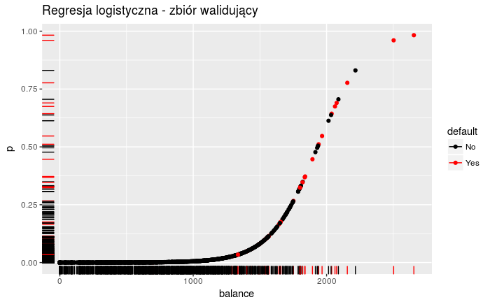

## 5.2 Krzywa ROC (*Receiver Operating Characteristic curve*)

Jest to wykres, na którym każdy punkt, determinowany przez wartości współczynników (False Positive rate; Czułość) powstał z osobnej macierzy pomyłek, stworzonej z użyciem innej wartości progu prawdopodobieństwa klasyfikacji (odcięcia).  
Przekątna odpowiada klasyfikatorowi losowemu.

### 5.2.1 Stepwise ROC

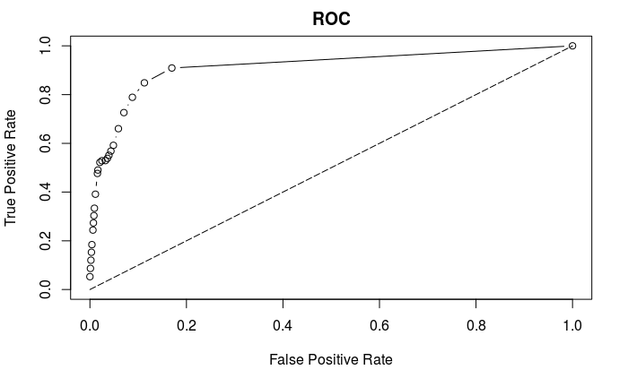

```r
rocCurve<-data.frame()
for(i in seq(from=1, to=0, by=-0.02)) {
  Default.pred<-rep("No", length(Default.probs))
  Default.pred[Default.probs > i]<-"Yes"
  same<-Default.pred==valVect
  different<-Default.pred!=valVect
  TPR<-sum(Default.pred[same]=="Yes") / sum(valVect=="Yes")
  FPR<-sum(Default.pred[different]=="Yes") / sum(valVect=="No")
  rocCurve<-rbind(rocCurve, data.frame(tpr=TPR, fpr=FPR))
}
spline<-smooth.spline(rocCurve$fpr, rocCurve$tpr, spar = 0.6)
plot(spline, ylim=c(0,1), type="b", main="ROC",
     xlab="False Positive Rate", ylab="True Positive Rate")
plot(function(x){x}, lty=5, add=TRUE)
```

### 5.2.2 Samplewise ROC

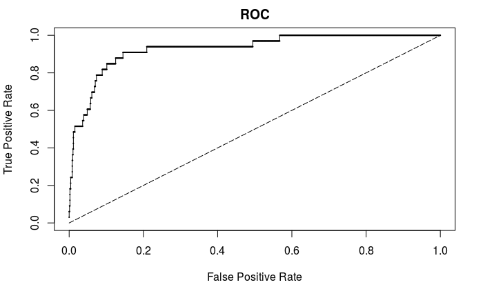

```r
rocCurve.fnc <- function(labels, scores) {
  labels <- labels[order(scores, decreasing=TRUE)]
  data.frame(tpr=cumsum(labels)/sum(labels), fpr=cumsum(!labels)/sum(!labels), labels)
}
rocCurve<-rocCurve.fnc(valVect=="Yes", Default.probs)
plot(rocCurve$fpr, rocCurve$tpr, ylim=c(0,1), type="o", pch=20, cex=.25, main="ROC",
     xlab="False Positive Rate", ylab="True Positive Rate")
plot(function(x){x}, lty=5, add=TRUE)
```

### 5.2.3 Zastosowanie pakietu `pROC`

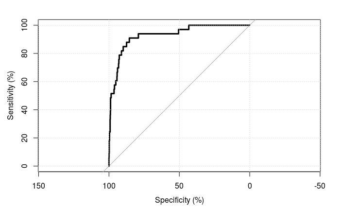

```r
library(pROC)
rocCurve<-roc(valVect, Default.probs, direction="<", percent=TRUE)
plot(rocCurve, ylim=c(0,100), xlim=c(100,0), lwd=3)
grid()
```

## 5.3 Area Under the Curve

Całka po krzywej ROC. Wartość **1** oznacza klasyfikator idealny, **0.5** losowy; wartości poniżej 0.5 oznaczają klasyfikator gorszy od losowego.

```r
print(rocCurve$auc)
```

```
Area under the curve: 92.87%
```

# 6 Prognoza

## 6.1 *Default ~ Student*

```r
est<-glm(default~student, data=Default, family=binomial)
```

```
Call:
glm(formula = default ~ student, family = binomial, data = Default)

Deviance Residuals:
    Min       1Q   Median       3Q      Max
-0.2970  -0.2970  -0.2434  -0.2434   2.6585

Coefficients:
            Estimate Std. Error z value Pr(>|z|)
(Intercept) -3.50413    0.07071  -49.55  < 2e-16 ***
studentYes   0.40489    0.11502    3.52 0.000431 ***
---
Signif. codes:  0 ‘***’ 0.001 ‘**’ 0.01 ‘*’ 0.05 ‘.’ 0.1 ‘ ’ 1

(Dispersion parameter for binomial family taken to be 1)

    Null deviance: 2920.6  on 9999  degrees of freedom
Residual deviance: 2908.7  on 9998  degrees of freedom
AIC: 2912.7

Number of Fisher Scoring iterations: 6
```

Prawdopodobieństwo *a posteriori* wystąpienia zadłużenia przy wiedzy (dowodzie, ang. *evidence*), że klient **jest studentem**.

```r
predict(est, newdata = data.frame(student='Yes'), type='response')
```

```
[1] "Pr(default=Yes|student=Yes)=4.31%"
```

Prawdopodobieństwo *a posteriori* wystąpienia zadłużenia przy wiedzy (dowodzie, ang. *evidence*), że klient **nie jest studentem**.

```r
predict(est, newdata = data.frame(student='No'), type='response')
```

```
[1] "Pr(default=Yes|student=No)=2.92%"
```

## 6.2 *Default ~ Student, Balance*

```r
est<-glm(default~balance+student, data=Default, family=binomial)
```

```
Call:
glm(formula = default ~ balance + student, family = binomial,
    data = Default)

Deviance Residuals:
    Min       1Q   Median       3Q      Max
-2.4578  -0.1422  -0.0559  -0.0203   3.7435

Coefficients:
              Estimate Std. Error z value Pr(>|z|)
(Intercept) -1.075e+01  3.692e-01 -29.116  < 2e-16 ***
balance      5.738e-03  2.318e-04  24.750  < 2e-16 ***
studentYes  -7.149e-01  1.475e-01  -4.846 1.26e-06 ***
---
Signif. codes:  0 ‘***’ 0.001 ‘**’ 0.01 ‘*’ 0.05 ‘.’ 0.1 ‘ ’ 1

(Dispersion parameter for binomial family taken to be 1)

    Null deviance: 2920.6  on 9999  degrees of freedom
Residual deviance: 1571.7  on 9997  degrees of freedom
AIC: 1577.7

Number of Fisher Scoring iterations: 8
```

Prawdopodobieństwo *a posteriori* wystąpienia zadłużenia przy wiedzy (dowodzie, ang. *evidence*), że klient **jest studentem**, a obciążenia na karcie to **$2000**.

```r
predict(est, newdata = data.frame(student='Yes', balance=2000), type='response')
```

```
[1] "Pr(default=Yes|student=Yes,balance=2000)=50.30%"
```

Prawdopodobieństwo *a posteriori* wystąpienia zadłużenia przy wiedzy (dowodzie, ang. *evidence*), że klient **nie jest studentem**, a obciążenia na karcie to **$2000**.

```r
predict(est, newdata = data.frame(student='No', balance=2000), type='response')
```

```
[1] "Pr(default=Yes|student=No,balance=2000)=67.41%"
```

# 7 Klasyfikacja wieloklasowa

Wartości nominalne zmiennej endogenicznej:

- **DH** - Disk Hernia
- **SL** - Spondylolisthesis
- **NO** - Normal

Wczytanie danych.

```r
data<-read.table('/usr/miswdm/column_3C.dat')
colnames(data)<-c(
  'pelvic incidence',
  'pelvic tilt',
  'lumbar lordosis angle',
  'sacral slope',
  'pelvic radius',
  'grade of spondylolisthesis',
  'class')
```

Podział na zbiór trenujący i walidujący metodą *hold-out*.

```r
partition<-createDataPartition(data$class, p=.7, list=FALSE)
data.train<-data[partition,]
data.test<-data[-partition,]
```

Funkcje pomocnicze.

```r
cls<-function(name) suppressWarnings(glm(class==name~., data=data.train, family=binomial))
pred<-function(row) names(which.max(vapply(classifiers,
                                           function(c) predict(c, row, type='response'), .0)))
```

Metoda **One-vs-All** (**One-vs-Rest**)

```r
classifiers=list(NO=cls('NO'), DH=cls('DH'), SL=cls('SL'))
for (i in 1:nrow(data.test)) data.test[i, 'pred']<-pred(data.test[i,])
cm<-as.matrix(table(Predicted=data.test$pred, Actual=data.test$class))
```

Macierz pomyłek.

```
         Actual
Predicted DH NO SL
       DH 10  2  1
       NO  8 28  2
       SL  0  0 42
```

## 7.1 Współczynniki klasyfikacji

Wartości pomocnicze.

```r
diag = diag(cm)
rowsums = apply(cm, 1, sum)
colsums = apply(cm, 2, sum)
```

### 7.1.1 Trafność (ang. *Accuracy*)

```r
sum(diag) / sum(cm)
```

```
[1] "Accuracy: 86.02%"
```

### 7.1.2 Średnia precyzja (ang. *Mean precision*)

```r
precision = diag / rowsums
mean(precision)
```

```
[1] 0.8353576
```

### 7.1.3 Średnia czułość (ang. *Mean recall*)

```r
recall = diag / colsums
mean(recall)
```

```
[1] 0.8074074
```

### 7.1.4 Średnia F-miara (ang. *Mean F1 score*)

```r
f1 = 2 * precision * recall / (precision + recall)
mean(f1)
```

```
[1] 0.8114026
```